# Research Topic: The Factors Associated with Suicide Rates

Group Blackcurrant: Wenxin Zhou, Junpeng Jiang, Zuxuan Huai, Lijia Liu

# Introduction: Background information

Mental health is very important to all of us in our fast-paced life. Many NGOs and schools are holding a lot of activities in promoting a healthy mental state. When we browsing data on Kaggle, one data about suicide rates caught our eyes. We are very interested in suicide rates, which is severe mental health to the extreme.

Supposedly, people in developed countries should be in a good economic state and should have good lives. On the other hand, we think that these developed countries also encourage individuality and people are likely to be open about suicides. We would like to take a deeper look at the data to find out what factors are associated with suicide rates. The dataset has suicide and economic records from 101 countries for different ages and generations. a statistic composite index of life expectancy, education, and per capita income indicators, which are used to rank countries into four tiers of human development.

Variables in our dataset includes:

- Year
- Country
- Age
- Sex: Female & Male
- Suicide Rates: suicides/100k population
- GDP
- GDP per capita
- HDI: a statistic composite index of life expectancy, education, and per capita income indicators, which are used to rank countries into four tiers of human development.
- Generations: people born in
  - 2000 to present: Generation Z.
  - 1980 to 2000: Millennials
  - 1965 to 1979: Generation X.
  - 1946 to 1964: Boomers.
  - 1925 to 1945: Silent Generation.
  - 1900 to 1924: G.I. Generation.

Because the entire dataset has worldwide data and is hard to find insights, we want to narrow down our research area into two regions. We want to compare regions where we normally associated with good social welfare and peaceful life, and where with political conflicts and constant wars. We choose middle east and northern Europe as these two regions and select five countries with the largest population within these two regions.

# Exploratory Data Analysis

```python
import numpy as np
import pandas as pd
import matplotlib.pyplot as plt
import seaborn as sns
```

We download our dataset from Kaggle, and the variables in the dataset are : country,year,sex,age,suicide number, population, suicides/100k pop,gdp, gsp per capita, generation and HDI. The HDI data is not complete in our dataset so we find more official data and implement them into our dataset. Then we have HDI data from 1990 to 2017. For further analysis of suicide, we use suicide rate to represent suicides/100k pop.

```python
total = pd.read_csv('master.csv')
HDIdata = pd.read_csv('HDI.csv')
HDIdata = HDIdata.melt('Country')
HDIdata.rename(columns = {'variable':'year', 'value':'HDI', ' gdp':'gdp'}, inplace=True)
HDIdata['year'] = HDIdata.year.astype(int)
HDIdata['Country'] = HDIdata['Country'].str[1:]
HDIdata.head()
total = total.rename(columns = {'suicides/100k pop':'suicide_rate'})
total = total.rename(columns = {'gdp_per_capita':'gdpc'})
total = total.rename(columns = {' gdp':'gdp'})
#total['age'] = total['age'].astype('category')
#total = total.rename_categories({'5-14 years','15-24 years','25-34 years','35-54 years','55-74 years','75+ years'})
total = total.drop(columns='HDI')
total = pd.merge(total, HDIdata,  how='left', left_on=['country', 'year'], right_on = ['Country', 'year'])
total = total.drop(columns='Country')
total.rename(columns = {'HDI_y':'HDI'}, inplace=True)
total.head()
```

|  | country | year | sex | age | suicides_no | population | suicide_rate | country-year | gdp | gdpc | generation | HDI |
| --- | --- | --- | --- | --- | --- | --- | --- | --- | --- | --- | --- | --- |
| 0 | Albania | 1987.0 | male | 15-24 years | 21 | 312900 | 6.71 | Albania1987 | 2.156625e+09 | 796 | Generation X | NaN |
| 1 | Albania | 1987.0 | male | 35-54 years | 16 | 308000 | 5.19 | Albania1987 | 2.156625e+09 | 796 | Silent | NaN |
| 2 | Albania | 1987.0 | female | 15-24 years | 14 | 289700 | 4.83 | Albania1987 | 2.156625e+09 | 796 | Generation X | NaN |
| 3 | Albania | 1987.0 | male | 75+ years | 1 | 21800 | 4.59 | Albania1987 | 2.156625e+09 | 796 | G.I. Generation | NaN |
| 4 | Albania | 1987.0 | male | 25-34 years | 9 | 274300 | 3.28 | Albania1987 | 2.156625e+09 | 796 | Boomers | NaN |

We are interested in how suicide rate may differ in Middle East area and northern Europe. We choose 'Cyprus','Israel','Bahrain','Oman','Qatar' to represent Middle East countries and 'Iceland', 'Finland','Denmark','Norway','Sweden' to represent northern Europe countries.

```python
middleeastcountry=['Cyprus','Israel','Bahrain','Oman','Qatar']
northeuropecountry=['Iceland', 'Finland','Denmark','Norway','Sweden']
middleeast=total[total.country.isin(middleeastcountry)]
northeurope=total[total.country.isin(northeuropecountry)]
```

```python
northeurope.head()
```

|  | country | year | sex | age | suicides_no | population | suicide_rate | country-year | gdp | gdpc | generation | HDI |
| --- | --- | --- | --- | --- | --- | --- | --- | --- | --- | --- | --- | --- |
| 7418 | Denmark | 1994.0 | male | 75+ years | 89 | 131700 | 67.58 | Denmark1994 | 1.561623e+11 | 32034 | G.I. Generation | 0.824 |
| 7419 | Denmark | 1994.0 | male | 55-74 years | 189 | 448200 | 42.17 | Denmark1994 | 1.561623e+11 | 32034 | Silent | 0.824 |
| 7420 | Denmark | 1994.0 | male | 35-54 years | 279 | 755600 | 36.92 | Denmark1994 | 1.561623e+11 | 32034 | Boomers | 0.824 |
| 7421 | Denmark | 1994.0 | female | 75+ years | 70 | 230600 | 30.36 | Denmark1994 | 1.561623e+11 | 32034 | G.I. Generation | 0.824 |
| 7422 | Denmark | 1994.0 | male | 25-34 years | 85 | 414100 | 20.53 | Denmark1994 | 1.561623e+11 | 32034 | Boomers | 0.824 |

```python
middleeast.head()
```

|  | country | year | sex | age | suicides_no | population | suicide_rate | country-year | gdp | gdpc | generation | HDI |
| --- | --- | --- | --- | --- | --- | --- | --- | --- | --- | --- | --- | --- |
| 2636 | Bahrain | 1985.0 | male | 25-34 years | 7 | 67600 | 10.36 | Bahrain1985 | 3.651862e+09 | 9980 | Boomers | NaN |
| 2637 | Bahrain | 1985.0 | male | 35-54 years | 3 | 49700 | 6.04 | Bahrain1985 | 3.651862e+09 | 9980 | Silent | NaN |
| 2638 | Bahrain | 1985.0 | female | 35-54 years | 1 | 26900 | 3.72 | Bahrain1985 | 3.651862e+09 | 9980 | Silent | NaN |
| 2639 | Bahrain | 1985.0 | female | 15-24 years | 0 | 37800 | 0.00 | Bahrain1985 | 3.651862e+09 | 9980 | Generation X | NaN |
| 2640 | Bahrain | 1985.0 | female | 25-34 years | 0 | 27600 | 0.00 | Bahrain1985 | 3.651862e+09 | 9980 | Boomers | NaN |

Then we draw histograms and summaries for gdp,gdpc,suicide_rate, and HDI of Middle East countries. We can see that HDI has mean value of 0.832291 and does not have a clear trend. GDP has mean value of 8.028445e+10 and has a very high frequency in the first bin. GDPC has mean value of 30394.570866 and mostly falls between 0-25500. Suicide rate has mean value of 4.653661 and 50% of suicide rate is equal or below 1.89.

|  | gdp | gdpc | suicide_rate | HDI |
| --- | --- | --- | --- | --- |
| count | 1.016000e+03 | 1016.000000 | 1016.000000 | 920.000000 |
| mean | 8.028445e+10 | 30394.570866 | 4.653661 | 0.832291 |
| std | 7.927354e+10 | 21051.600958 | 7.369842 | 0.033468 |
| min | 3.392021e+09 | 7325.000000 | 0.000000 | 0.779000 |
| 25% | 2.040371e+10 | 17497.000000 | 0.000000 | 0.799000 |
| 50% | 4.453049e+10 | 23451.000000 | 1.890000 | 0.831000 |
| 75% | 1.251223e+11 | 33816.000000 | 6.185000 | 0.855000 |
| max | 3.084170e+11 | 93270.000000 | 66.180000 | 0.901000 |

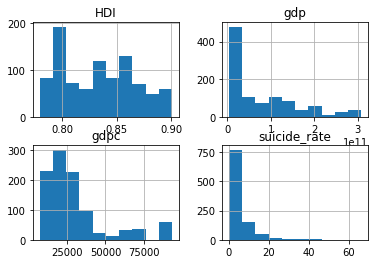

```python
middleeast[['gdp','gdpc','suicide_rate','HDI']].hist()
middleeast[['gdp','gdpc','suicide_rate','HDI']].describe()
```

Then we draw histograms and summaries for gdp,gdpc,suicide_rate, and HDI of Northern Europe countries. We can see that HDI has mean value of 0.884046 which is larger than Middle East countries. GDP has mean value of 2.043875e+11 which is higher than Middle East and the frequency distribution is not concentrated in one bin. GDPC has mean value of 44276.962617. Suicide rate has mean value of 15.445082 which is a lot higher than that of Middle East. We are quite surprise to find it and want to explore on suicide rate vs GDPC/HDI further.

|  | gdp | gdpc | suicide_rate | HDI |
| --- | --- | --- | --- | --- |
| count | 1.712000e+03 | 1712.000000 | 1712.000000 | 1532.000000 |
| mean | 2.043875e+11 | 44276.962617 | 15.445082 | 0.884046 |
| std | 1.543261e+11 | 19830.340628 | 14.749128 | 0.040050 |
| min | 2.939845e+09 | 13357.000000 | 0.000000 | 0.784000 |
| 25% | 9.423006e+10 | 29311.000000 | 4.775000 | 0.856000 |
| 50% | 1.786352e+11 | 38997.000000 | 10.960000 | 0.895000 |
| 75% | 2.837425e+11 | 55352.500000 | 22.852500 | 0.911000 |
| max | 5.787420e+11 | 109804.000000 | 90.060000 | 0.948000 |

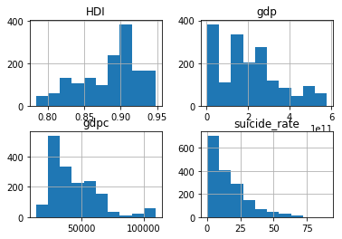

```python
northeurope[['gdp','gdpc','suicide_rate','HDI']].hist()
northeurope[['gdp','gdpc','suicide_rate','HDI']].describe()
```

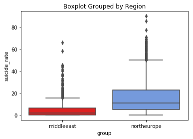

```python
middleeast['group']=['middleeast']*1016
northeurope['group']=['northeurope']*1712

palette=["red", "cornflowerblue"]
both=pd.concat([middleeast, northeurope])

#two areas
box_area = sns.boxplot(data = both,
                x = 'group',
                y = 'suicide_rate',
                palette = palette)

box_area.set_title('Boxplot Grouped by Region') #
plt.show()
```

When we break down into two regions, the suicide rates in northern Europe is much higher that suicide rates in middle east. It's surprising to find that the suicides in regions where people have better social welfare are more likely to commit to suicide.

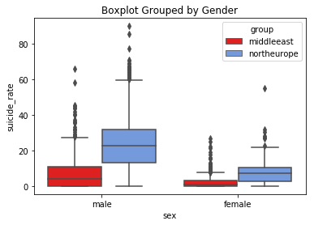

```python
# by gender
box_gender = sns.boxplot(data = both,
                hue = 'group', # different colors for different 'cls'
                x = 'sex',
                y = 'suicide_rate',
                palette = palette
                        )

box_gender.set_title('Boxplot Grouped by Gender') # You can change the title here
plt.show()
```

In both regions, males are more likely to commit to suicide than females. In general, suicide rates are much higher in Northern Europe.

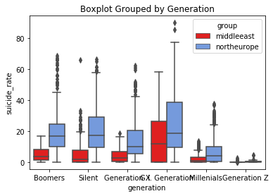

```python
# by generation
box_generation = sns.boxplot(data = both,
                hue = 'group', # different colors for different 'cls'
                x = 'generation',
                y = 'suicide_rate',
                palette = palette)

box_generation.set_title('Boxplot Grouped by Generation') #
plt.show()
```

G.I. Generation, followed by Generation Silence have the highest suicide rates.

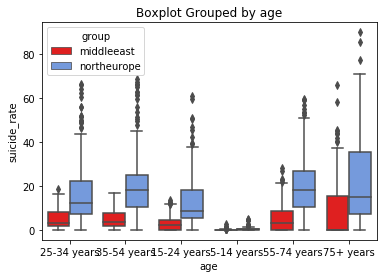

```python
# by age
box_age = sns.boxplot(data = both,
                hue = 'group', # different colors for different 'cls'
                x = 'age',
                y = 'suicide_rate',
                palette = palette)

box_age.set_title('Boxplot Grouped by age') #
plt.show()
```

## Middle East

#### The paired plots give a general view of the distribution of gdp, gdpc, HDI and suicide rate , it also reflects how different variables are related to each other.

- From the plots we can see the gdp, gdpc show positively relationship with HDI.
- The first bin of suicide rate are extremely high, in the following analysis we find that there are lots of zeros and there are some other factors that may leads to the zeros.
- In addition, the plots for suicide rate and other variables seems like a cluster of random points and do not have a trend. This may caused the fact that for each year and each country, there are several replications of these values due to age group and gender.
- Since gdp is not standardized, we choose to use gdpc instead of gpd in the following analysis.

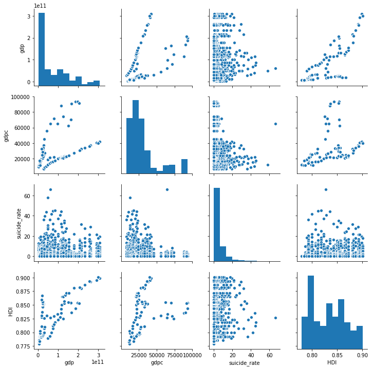

```python
sns.pairplot(middleeast[['gdp','gdpc','suicide_rate','HDI']])
#sns.pairplot(middleeast[['gdp','gdpc','suicide_rate','HDI','country']].dropna(), hue="country")
```

### GDPC and Suicide Rate

|  | gdpc | suicide_rate |
| --- | --- | --- |
| gdpc | 1.00000 | -0.30887 |
| suicide_rate | -0.30887 | 1.00000 |

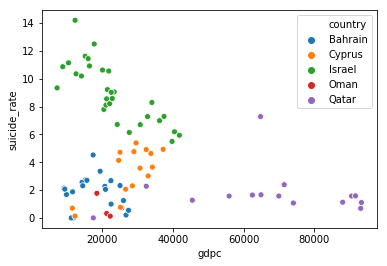

```python
gdp_plot = middleeast.groupby([middleeast.country, middleeast.year]).gdpc.mean()
suicide_rate_plot = middleeast.groupby([middleeast.country, middleeast.year]).suicide_rate.mean()

joint = pd.DataFrame(gdp_plot).join(pd.DataFrame(suicide_rate_plot))

#plt.scatter(joint.gdpc, joint.suicide_rate)
joint_reset = joint.reset_index()

sns.scatterplot(joint_reset.gdpc, joint_reset.suicide_rate, hue = joint_reset.country)
joint.corr()
```

- Over all there is a negative relationship between gdpc,grouped by year and country, and their average suicide rates.
- However, if we analysis in terms of different country, we notice the previous trend does not exist. In Middle East each one of the country follows a different pattern. For example, Israel has a negative relationship, and Cyprus has a positive one.

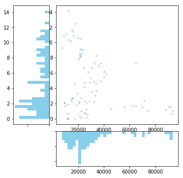

```python
# Set up the axes with gridspec
fig = plt.figure(figsize=(6, 6))
grid = plt.GridSpec(4, 4)   ## 4 x 4 grid
main_ax = fig.add_subplot(grid[:-1, 1:]) # vertically, we start at the beginning, and leave one space


# horizontally, we start at the second and go to the end
y_hist = fig.add_subplot(grid[:-1, 0 ], xticklabels=[], sharey=main_ax) # share y axis with main, no ticks on x
x_hist = fig.add_subplot(grid[ -1, 1:], yticklabels=[], sharex=main_ax) # share x axis with main, no ticks on y

# scatter points on the main axes
main_ax.plot(joint_reset.gdpc, joint_reset.suicide_rate, 'o', markersize=3, alpha=0.2)

# histogram on the attached axes
x_hist.hist(joint_reset.gdpc, 40, histtype='stepfilled', orientation='vertical', color='skyblue')
x_hist.invert_yaxis()

y_hist.hist(joint_reset.suicide_rate, 40, histtype='stepfilled', orientation='horizontal', color='skyblue')
y_hist.invert_xaxis()
```

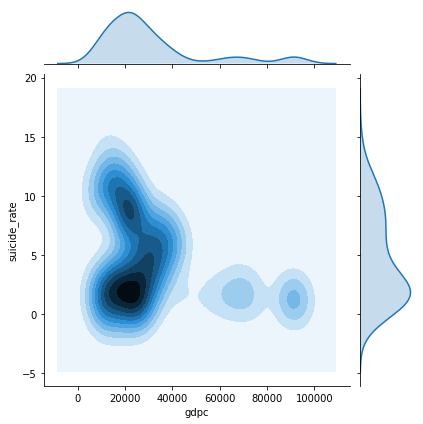

```python
sns.jointplot(x="gdpc", y="suicide_rate", data=joint_reset, kind="kde")
```

- These two plots give not only the relation between gdpc and suicide rate, but also shows each of the variable's distribution.

### HDI vs. Suicide Rate

|  | HDI | suicide_rate |
| --- | --- | --- |
| HDI | 1.000000 | 0.395003 |
| suicide_rate | 0.395003 | 1.000000 |

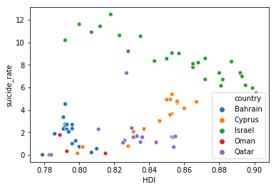

```python
mid_nona = middleeast.dropna(subset=['HDI'])
hdiplot = mid_nona.groupby([mid_nona.country, mid_nona.year]).HDI.mean()
suiplot = mid_nona.groupby([mid_nona.country, mid_nona.year]).suicide_rate.mean()

hdijoint = pd.DataFrame(hdiplot).join(pd.DataFrame(suiplot))

hdi_reset = hdijoint.reset_index()

sns.scatterplot(hdi_reset.HDI, hdi_reset.suicide_rate, hue = hdi_reset.country)
hdijoint.corr()
```

- Similarly we plot HDI grouped by year and country versus mean suicide rate grouped by year and country. And this relation is also distinctive among countries in middle east.
- In Israel, HDI and gdpc are negatively related to suicide rate, but in Cyprus, there is positive relationship.

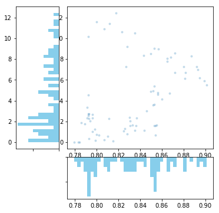

```python
# Set up the axes with gridspec
fig = plt.figure(figsize=(6, 6))
grid = plt.GridSpec(4, 4)   ## 4 x 4 grid
main_ax = fig.add_subplot(grid[:-1, 1:]) # vertically, we start at the beginning, and leave one space


# horizontally, we start at the second and go to the end
y_hist = fig.add_subplot(grid[:-1, 0 ], xticklabels=[], sharey=main_ax) # share y axis with main, no ticks on x
x_hist = fig.add_subplot(grid[ -1, 1:], yticklabels=[], sharex=main_ax) # share x axis with main, no ticks on y

# scatter points on the main axes
main_ax.plot(hdi_reset.HDI, hdi_reset.suicide_rate, 'o', markersize=3, alpha=0.2)

# histogram on the attached axes
x_hist.hist(hdi_reset.HDI, 40, histtype='stepfilled', orientation='vertical', color='skyblue')
x_hist.invert_yaxis()

y_hist.hist(hdi_reset.suicide_rate, 40, histtype='stepfilled', orientation='horizontal', color='skyblue')
y_hist.invert_xaxis()
```

## Northern Europe

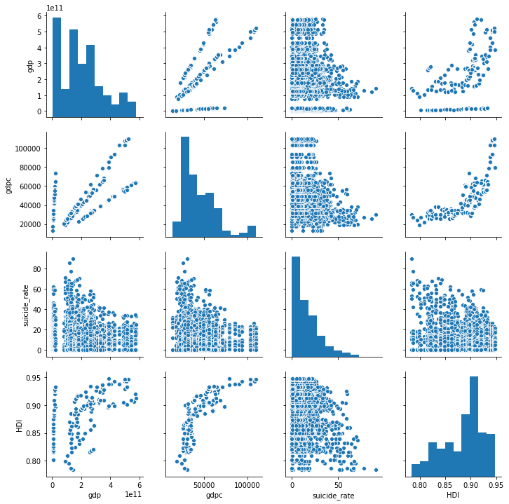

```python
sns.pairplot(northeurope[['gdp','gdpc','suicide_rate','HDI']])
#sns.pairplot(northeurope[['gdp','gdpc','suicide_rate','HDI','country']].dropna(), hue="country")
```

- Similarly, in the plots we can see the HDI,gdp and gdpc are positively correlated, especially the plot of HDI and gdpc looks very similar to plot of a quadratic function with positive coefficient.

### GDPC vs Suicide Rate

|  | gdpc | suicide_rate |
| --- | --- | --- |
| gdpc | 1.000000 | -0.493508 |
| suicide_rate | -0.493508 | 1.000000 |

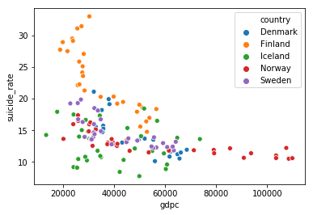

```python
gdp_plot2 = northeurope.groupby([northeurope.country, northeurope.year]).gdpc.mean()
suicide_rate_plot2 = northeurope.groupby([northeurope.country, northeurope.year]).suicide_rate.mean()

joint2 = pd.DataFrame(gdp_plot2).join(pd.DataFrame(suicide_rate_plot2))

#plt.scatter(joint.gdpc, joint.suicide_rate)
joint_reset2 = joint2.reset_index()

sns.scatterplot(joint_reset2.gdpc, joint_reset2.suicide_rate, hue = joint_reset2.country)
joint2.corr()
```

- The correlation between GDPC and suicide rate is -0.493508, which is pretty big and may be a significant factor effecting suicide rate.
- Over all there is a negative relationship between gdpc,grouped by year and country, and their average suicide rates.
- Different from plot of Middle East, there is no strange behavior(trend) between countries. So when we fit the model for Northen Europe areas we look at the countries as a whole.

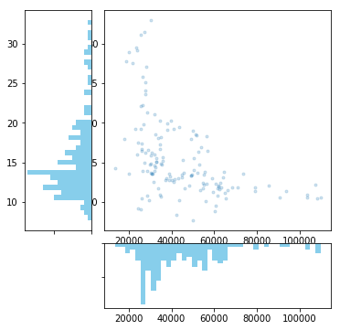

```python
# Set up the axes with gridspec
fig = plt.figure(figsize=(6, 6))
grid = plt.GridSpec(4, 4)   ## 4 x 4 grid
main_ax = fig.add_subplot(grid[:-1, 1:]) # vertically, we start at the beginning, and leave one space


# horizontally, we start at the second and go to the end
y_hist = fig.add_subplot(grid[:-1, 0 ], xticklabels=[], sharey=main_ax) # share y axis with main, no ticks on x
x_hist = fig.add_subplot(grid[ -1, 1:], yticklabels=[], sharex=main_ax) # share x axis with main, no ticks on y

# scatter points on the main axes
main_ax.plot(joint_reset2.gdpc, joint_reset2.suicide_rate, 'o', markersize=3, alpha=0.2)

# histogram on the attached axes
x_hist.hist(joint_reset2.gdpc, 40, histtype='stepfilled', orientation='vertical', color='skyblue')
x_hist.invert_yaxis()

y_hist.hist(joint_reset2.suicide_rate, 40, histtype='stepfilled', orientation='horizontal', color='skyblue')
y_hist.invert_xaxis()
```

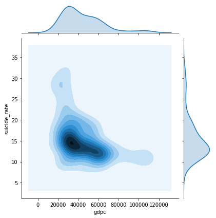

```python
sns.jointplot(x="gdpc", y="suicide_rate", data=joint_reset2, kind="kde")
```

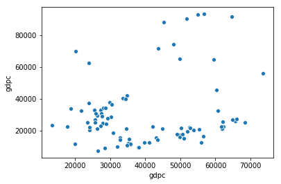

```python
sns.scatterplot(joint_reset2.gdpc, joint_reset.gdpc)
```

### HDI vs. Suicide Rate

|  | HDI | suicide_rate |
| --- | --- | --- |
| HDI | 1.00000 | -0.62295 |
| suicide_rate | -0.62295 | 1.00000 |

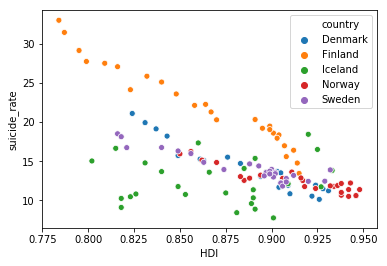

```python
europe_nona = northeurope.dropna(subset=['HDI'])
hdiplot2 = europe_nona.groupby([europe_nona.country, europe_nona.year]).HDI.mean()
suiplot2 = europe_nona.groupby([europe_nona.country, europe_nona.year]).suicide_rate.mean()

hdijoint2 = pd.DataFrame(hdiplot2).join(pd.DataFrame(suiplot2))

hdi_reset2 = hdijoint2.reset_index()

sns.scatterplot(hdi_reset2.HDI, hdi_reset2.suicide_rate, hue = hdi_reset2.country)
hdijoint2.corr()
```

- The correlation between HDI and suicide rate is -0.62295, which is pretty big and may be a significant factor effecting suicide rate.
- Over all there is a negative relationship between HDI grouped by year and country versus mean suicide rate grouped by year and country.
- Similar to gdpc, there is no strange behavior(trend) between countries for HDI.

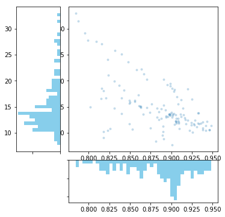

```python
# Set up the axes with gridspec
fig = plt.figure(figsize=(6, 6))
grid = plt.GridSpec(4, 4)   ## 4 x 4 grid
main_ax = fig.add_subplot(grid[:-1, 1:]) # vertically, we start at the beginning, and leave one space


# horizontally, we start at the second and go to the end
y_hist = fig.add_subplot(grid[:-1, 0 ], xticklabels=[], sharey=main_ax) # share y axis with main, no ticks on x
x_hist = fig.add_subplot(grid[ -1, 1:], yticklabels=[], sharex=main_ax) # share x axis with main, no ticks on y

# scatter points on the main axes
main_ax.plot(hdi_reset2.HDI, hdi_reset2.suicide_rate, 'o', markersize=3, alpha=0.2)

# histogram on the attached axes
x_hist.hist(hdi_reset2.HDI, 40, histtype='stepfilled', orientation='vertical', color='skyblue')
x_hist.invert_yaxis()

y_hist.hist(hdi_reset2.suicide_rate, 40, histtype='stepfilled', orientation='horizontal', color='skyblue')
y_hist.invert_xaxis()
```

## Exploratory Analysis Summary

- Overall there exist significant distinction of suicide rate between Middle East and North Europe, each represented by 5 countries. North Europe has higher suicide rate than in Middle East

### Categorical

- In terms of categorical variables: gender: we see that in both regions, males has significantly higher suicide rate than female. Since in each country the data takes the same number of males and females, the number of men and women is not an indicator of the difference in suicide rate.
- In both age and generation, the boxplots are consistent with the difference in suicide rates between two regions. For almost all individuals in every age or generation group, North Europe has higher suicide rate in general.

### Numeric

- In North Europe, HDI and GDP per capital both have negative relationship with suicide rates. However in middle east, the relationship between HDI,GDP and suicide rate is case-sensitive. For example in Israel, the relationship of HDI, GDP and suicide rate is similar to those in North Europe. One possible explanation is that Israel is the only developed country in Middle east, the way country economy interact with people's benefits may be very similar to countries in Europe.

### Insights on Modeling

- Since some factors interact differently, we separately construct models for two regions. We mainly analysis age, gender, generation, HDI and gdp per capital as predictors, and suicide rate as response variable.

# Data Modeling

We find that HDI seems to have a similar trend, so plot the scatterplot of HDI and GDPC to see their general trend.

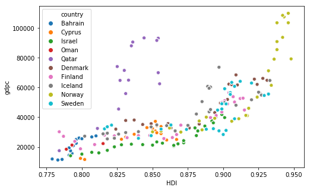

```python
plt.figure(figsize=(8, 5))
sns.scatterplot(both.HDI,both.gdpc,hue = both.country)
```

Before modeling, we would to have a look a the suicide rate variable.

From the histogram, we find that there are a lot of numbers are zero. Zero suicide rate may be a country really has a low suicide rate, or the value could be missing and just reported as zero for the country to look good. So we counted the number of zeros for each country and made a choropleth map graph to give us a better visualization.

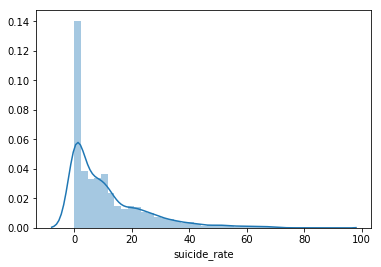

```python
sns.distplot(both.suicide_rate)
```

```python
import plotly.plotly as py
import plotly.graph_objs as go
import pandas as pd
from plotly.offline import download_plotlyjs,init_notebook_mode,plot,iplot


zero = both[both.suicide_rate == 0].groupby('country').count()
zero['country']=zero.index
zero1 = zero[['country','group']]
zero1['code']=['BHR','CYP','DNK','FIN','ISL','ISR','NOR','OMN','QAT','SWE']
zero1
```

| country | country | group | code |
| --- | --- | --- | --- |
| Bahrain | Bahrain | 146 | BHR |
| Cyprus | Cyprus | 80 | CYP |
| Denmark | Denmark | 20 | DNK |
| Finland | Finland | 15 | FIN |
| Iceland | Iceland | 118 | ISL |
| Israel | Israel | 20 | ISR |
| Norway | Norway | 14 | NOR |
| Oman | Oman | 25 | OMN |
| Qatar | Qatar | 96 | QAT |
| Sweden | Sweden | 7 | SWE |

```python
import plotly
import plotly.plotly as py
import plotly.figure_factory as ff
plotly.tools.set_credentials_file(username='HuaiWendy', api_key='VJyaxC8XzQ6VlCJDJVTP')

data1 = [dict(type='choropleth',
            locations = zero1['code'],
            z = zero1['group'],
            text = zero1['country'],
              colorscale='Portland',
            colorbar = {'title' : 'number of 0 suicide rates in countries'})]

layout = dict(title = 'Zero Suicide Rates',
              geo = dict(showframe = False,
                         projection = {'type':'mercator'}))


fig = go.Figure(data = data1, layout = layout)
py.iplot(fig, filename = 'd3-world-map')
```

[interactive chart not shown]

The choropleth map graph gives a better visualization of the countries where there are many zeros in the dataset. We think that 0 suicide rates is really hard to achieve and this graph and the table above show that certain countries indeed have many zeros. So in the modeling part, we decide to fit models both with and without zeros.

## Models

```python
from sklearn import linear_model
import statsmodels.api as sm
import statsmodels.formula.api as smf
```

```python
northeurope = northeurope.dropna()
middleeast = middleeast.dropna()
```

```python
middleeast['suicide_rate_mod'] = middleeast.suicide_rate.pow(1/5)
```

```python
israel = middleeast[middleeast.country == 'Israel']
Cyprus=middleeast[middleeast.country == 'Cyprus']
```

```python
middleeast.loc[middleeast.age == "15-24 years", 'age'] = '15-54'
middleeast.loc[middleeast.age == "25-34 years", 'age'] = '15-54'
middleeast.loc[middleeast.age == "35-54 years", 'age'] = '15-54'
middleeast['suicide_rate'].groupby(middleeast['age']).describe()
```

| age | count | mean | std | min | 25% | 50% | 75% | max |
| --- | --- | --- | --- | --- | --- | --- | --- | --- |
| 15-54 | 462.0 | 4.309221 | 4.257334 | 0.0 | 1.215 | 2.945 | 6.7450 | 18.55 |
| 5-14 years | 150.0 | 0.142533 | 0.342002 | 0.0 | 0.000 | 0.000 | 0.1575 | 2.53 |
| 55-74 years | 154.0 | 4.934481 | 6.026387 | 0.0 | 0.000 | 2.870 | 7.6775 | 26.69 |
| 75+ years | 154.0 | 7.889416 | 12.729837 | 0.0 | 0.000 | 0.000 | 12.2000 | 66.18 |

Since 15-24,25-34,35-54 age groups have similar distribution, we combine them to one group

#### Start from thinking about fitting a model to the entire middleeast area. We use the OLS model to fit it.

```python
# middleeast OLS
model_M = smf.ols('suicide_rate_mod ~ sex + age + generation + gdpc + HDI', data = middleeast)
results_M = model_M.fit()
results_M.summary()
```

OLS Regression Results

[output not shown]

[output not shown]

| Omnibus: | 40.818 | Durbin-Watson: | 0.823 |
| --- | --- | --- | --- |
| Prob(Omnibus): | 0.000 | Jarque-Bera (JB): | 36.239 |
| Skew: | -0.422 | Prob(JB): | 1.35e-08 |
| Kurtosis: | 2.516 | Cond. No. | 13.8 |

Warnings:  
[1] Standard Errors assume that the covariance matrix of the errors is correctly specified.

#### Use cross validation to train our model for the entire Middle East area

```python
# middleeast cross validation
from sklearn.model_selection import train_test_split
X_middleeast = middleeast[[ 'sex' , 'age' , 'generation' , 'HDI' , 'gdpc']]
X_middleeast.dropna()
X_train, X_test, y_train, y_test = train_test_split(X_middleeast, middleeast.suicide_rate_mod, test_size=0.3, random_state=0)


X_train['suicide_rate_mod'] = y_train
X_train.head()

cvmodel = smf.ols('suicide_rate_mod ~ sex + age + generation + HDI + gdpc', data = X_train)
resultsCV = cvmodel.fit()
cvPredictionLM = resultsCV.predict(X_test)
#MSE
np.mean((cvPredictionLM - y_test)**2)
```

```
0.27168414932966395
```

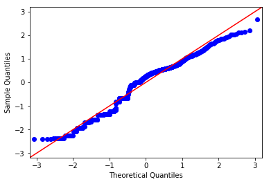

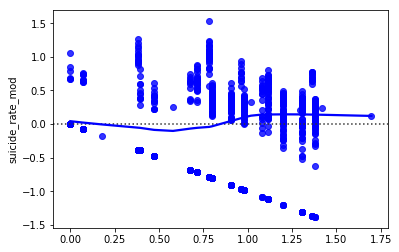

```python
res_M = results_M.resid
fig_M = sm.qqplot(res_M,fit=True, line='45')
plt.show()

sns.residplot(results_M.fittedvalues, middleeast.suicide_rate_mod, lowess=True, color="b")
```

Middle East OLS analysis: First, we build a simple liner model with all the mentioned variables to see the effect of each of them on suicide rate by region. By fitting a linear model for middle east, we have seen that not all "age" have p-values below 5% significant level. For the insignificant levels, we revisited the boxplots from data exploration and applied grouping by similar mean and variance. For example, in age group, 15-24, 25-34 and 35-54 exhibits similar spread. Therefore, these groups are combined to a larger group for the model. After we have done such data modification base on the summary output from our model, cross validation is used to further aid our analysis. Applying cross validation at 70-30 split to compare the effect of our data modification and variable selection, we manage to bring the MSE down to 0.2717. From the QQplot,we can find it's normal, but residual plot is not better.

#### Then we try to fit a GLM modelto the entire area.

```python
#middleeast GLM
glmmodel_M = smf.glm('suicide_rate_mod ~  sex + age + generation + gdpc + HDI', data = middleeast, family=sm.families.Gaussian())
glmresults_M = glmmodel_M.fit()
glmresults_M.summary()
```

Generalized Linear Model Regression Results

| Dep. Variable: | suicide_rate_mod | No. Observations: | 920 |
| --- | --- | --- | --- |
| Model: | GLM | Df Residuals: | 908 |
| Model Family: | Gaussian | Df Model: | 11 |
| Link Function: | identity | Scale: | 0.24006 |
| Method: | IRLS | Log-Likelihood: | -643.02 |
| Date: | Thu, 06 Jun 2019 | Deviance: | 217.97 |
| Time: | 11:09:25 | Pearson chi2: | 218. |
| No. Iterations: | 3 | Covariance Type: | nonrobust |

|  | coef | std err | z | P>\|z\| | [0.025 | 0.975] |
| --- | --- | --- | --- | --- | --- | --- |
| Intercept | -7.0756 | 0.432 | -16.394 | 0.000 | -7.922 | -6.230 |
| sex[T.male] | 0.4018 | 0.032 | 12.436 | 0.000 | 0.338 | 0.465 |
| age[T.5-14 years] | -0.5961 | 0.070 | -8.516 | 0.000 | -0.733 | -0.459 |
| age[T.55-74 years] | -0.4873 | 0.087 | -5.589 | 0.000 | -0.658 | -0.316 |
| age[T.75+ years] | -0.9101 | 0.109 | -8.347 | 0.000 | -1.124 | -0.696 |
| generation[T.G.I. Generation] | 0.9692 | 0.128 | 7.559 | 0.000 | 0.718 | 1.221 |
| generation[T.Generation X] | -0.1145 | 0.059 | -1.947 | 0.052 | -0.230 | 0.001 |
| generation[T.Generation Z] | -0.5042 | 0.105 | -4.813 | 0.000 | -0.709 | -0.299 |
| generation[T.Millenials] | -0.3051 | 0.062 | -4.927 | 0.000 | -0.426 | -0.184 |
| generation[T.Silent] | 0.2127 | 0.087 | 2.455 | 0.014 | 0.043 | 0.382 |
| gdpc | -5.667e-06 | 8.53e-07 | -6.643 | 0.000 | -7.34e-06 | -4e-06 |
| HDI | 9.9679 | 0.527 | 18.897 | 0.000 | 8.934 | 11.002 |

```python
from sklearn.model_selection import train_test_split
X_middleeast = middleeast[['sex' , 'age' , 'generation' , 'HDI' , 'gdpc']]
X_middleeast.dropna()
X_train, X_test, y_train, y_test = train_test_split(X_middleeast, middleeast.suicide_rate_mod, test_size=0.3, random_state=0)


X_train['suicide_rate'] = y_train
X_train.head()

cvmodel = smf.glm('suicide_rate ~ sex + age + generation + HDI + gdpc', data = X_train)
resultsCV = cvmodel.fit()
cvPredictionLM = resultsCV.predict(X_test)
#MS
np.mean((cvPredictionLM - y_test)**2)
```

```
0.27168414932966395
```

Middle East GLM analysis: A similar approach is adopted by using generalized linear model. GLM is considered as these data are repeated measurements by year so we suspect the observations are not linearly independent. Using the same process as the linear model, we have seen similar effects from the predictors, indicating similar conclusions can be drawn.

- Since in the previous analysis, we see HDI and gdpc are very correlated, there might exist multicollinearity in the model, we want to then construct models for countries with typical trend Israel and Cyprus.
- While Israel has a negative relation and Cyprus has a positive relation. So we do the case by case model for Middle East area, that is we fit the model to only Israel and only Cyprus.

```python
#only fit israel
model_i = smf.ols('suicide_rate_mod ~  sex + age + generation + HDI + gdpc', data = israel)
results_i = model_i.fit()
results_i.summary()
```

OLS Regression Results

| Dep. Variable: | suicide_rate_mod | R-squared: | 0.884 |
| --- | --- | --- | --- |
| Model: | OLS | Adj. R-squared: | 0.879 |
| Method: | Least Squares | F-statistic: | 174.5 |
| Date: | Thu, 06 Jun 2019 | Prob (F-statistic): | 8.00e-131 |
| Time: | 09:38:54 | Log-Likelihood: | 147.00 |
| No. Observations: | 312 | AIC: | -266.0 |
| Df Residuals: | 298 | BIC: | -213.6 |
| Df Model: | 13 |  |  |
| Covariance Type: | nonrobust |  |  |

|  | coef | std err | t | P>\|t\| | [0.025 | 0.975] |
| --- | --- | --- | --- | --- | --- | --- |
| Intercept | 1.9796 | 0.484 | 4.092 | 0.000 | 1.027 | 2.932 |
| sex[T.male] | 0.3833 | 0.018 | 21.900 | 0.000 | 0.349 | 0.418 |
| age[T.25-34 years] | 0.0878 | 0.036 | 2.433 | 0.016 | 0.017 | 0.159 |
| age[T.35-54 years] | 0.1785 | 0.056 | 3.197 | 0.002 | 0.069 | 0.288 |
| age[T.5-14 years] | -0.8462 | 0.040 | -20.901 | 0.000 | -0.926 | -0.766 |
| age[T.55-74 years] | 0.3025 | 0.088 | 3.454 | 0.001 | 0.130 | 0.475 |
| age[T.75+ years] | 0.4613 | 0.103 | 4.463 | 0.000 | 0.258 | 0.665 |
| generation[T.G.I. Generation] | 0.0860 | 0.081 | 1.065 | 0.288 | -0.073 | 0.245 |
| generation[T.Generation X] | 0.0400 | 0.045 | 0.896 | 0.371 | -0.048 | 0.128 |
| generation[T.Generation Z] | 0.2688 | 0.099 | 2.724 | 0.007 | 0.075 | 0.463 |
| generation[T.Millenials] | 0.1037 | 0.067 | 1.538 | 0.125 | -0.029 | 0.236 |
| generation[T.Silent] | -0.0393 | 0.056 | -0.702 | 0.483 | -0.149 | 0.071 |
| HDI | -0.9271 | 0.632 | -1.468 | 0.143 | -2.170 | 0.316 |
| gdpc | -4.037e-06 | 2.51e-06 | -1.608 | 0.109 | -8.98e-06 | 9.02e-07 |

| Omnibus: | 99.517 | Durbin-Watson: | 2.311 |
| --- | --- | --- | --- |
| Prob(Omnibus): | 0.000 | Jarque-Bera (JB): | 658.984 |
| Skew: | -1.131 | Prob(JB): | 8.01e-144 |
| Kurtosis: | 9.751 | Cond. No. | 2.44e+06 |

Warnings:  
[1] Standard Errors assume that the covariance matrix of the errors is correctly specified.  
[2] The condition number is large, 2.44e+06. This might indicate that there are  
strong multicollinearity or other numerical problems.

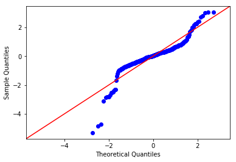

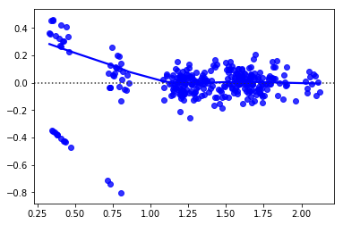

```python
res_i = results_i.resid
fig_i = sm.qqplot(res_i,fit=True, line='45')
plt.show()
sns.residplot(results_i.fittedvalues, res_i, lowess=True, color="b")
```

```python
#only fit Cyprus
model_c = smf.ols('suicide_rate_mod ~  sex + age + generation + gdpc + HDI', data = Cyprus)
results_c = model_c.fit()
results_c.summary()
```

OLS Regression Results

| Dep. Variable: | suicide_rate_mod | R-squared: | 0.607 |
| --- | --- | --- | --- |
| Model: | OLS | Adj. R-squared: | 0.575 |
| Method: | Least Squares | F-statistic: | 19.45 |
| Date: | Thu, 06 Jun 2019 | Prob (F-statistic): | 5.74e-27 |
| Time: | 09:40:31 | Log-Likelihood: | -105.87 |
| No. Observations: | 178 | AIC: | 239.7 |
| Df Residuals: | 164 | BIC: | 284.3 |
| Df Model: | 13 |  |  |
| Covariance Type: | nonrobust |  |  |

|  | coef | std err | t | P>\|t\| | [0.025 | 0.975] |
| --- | --- | --- | --- | --- | --- | --- |
| Intercept | -11.6434 | 2.906 | -4.007 | 0.000 | -17.381 | -5.906 |
| sex[T.male] | 0.4922 | 0.068 | 7.186 | 0.000 | 0.357 | 0.627 |
| age[T.25-34 years] | 0.1644 | 0.141 | 1.169 | 0.244 | -0.113 | 0.442 |
| age[T.35-54 years] | 0.2997 | 0.222 | 1.348 | 0.179 | -0.139 | 0.739 |
| age[T.5-14 years] | -0.3072 | 0.183 | -1.682 | 0.094 | -0.668 | 0.053 |
| age[T.55-74 years] | 0.1670 | 0.323 | 0.517 | 0.606 | -0.471 | 0.805 |
| age[T.75+ years] | -0.4401 | 0.378 | -1.165 | 0.246 | -1.186 | 0.306 |
| generation[T.G.I. Generation] | 0.3153 | 0.353 | 0.893 | 0.373 | -0.382 | 1.012 |
| generation[T.Generation X] | -0.0034 | 0.183 | -0.019 | 0.985 | -0.365 | 0.358 |
| generation[T.Generation Z] | -0.7622 | 0.372 | -2.050 | 0.042 | -1.496 | -0.028 |
| generation[T.Millenials] | -0.1751 | 0.270 | -0.649 | 0.517 | -0.708 | 0.358 |
| generation[T.Silent] | 0.0364 | 0.187 | 0.195 | 0.846 | -0.332 | 0.405 |
| gdpc | 9.934e-06 | 8.42e-06 | 1.179 | 0.240 | -6.7e-06 | 2.66e-05 |
| HDI | 14.2445 | 3.802 | 3.746 | 0.000 | 6.737 | 21.752 |

| Omnibus: | 4.092 | Durbin-Watson: | 1.666 |
| --- | --- | --- | --- |
| Prob(Omnibus): | 0.129 | Jarque-Bera (JB): | 4.012 |
| Skew: | -0.367 | Prob(JB): | 0.135 |
| Kurtosis: | 2.957 | Cond. No. | 4.01e+06 |

Warnings:  
[1] Standard Errors assume that the covariance matrix of the errors is correctly specified.  
[2] The condition number is large, 4.01e+06. This might indicate that there are  
strong multicollinearity or other numerical problems.

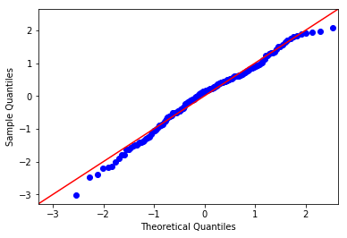

```python
res_c = results_c.resid
fig_c= sm.qqplot(res_c,fit=True, line='45')
plt.show()
```

Analysis: From the two countries, by fitting a linear model for Israel, we have seen that "HDI","GDPC" and not all "generation" have p-values above 5% significant level. And "GDPC", "age" and not all "generation" have p-values above 5% significant level. But there variables are all significant in the Middle East area model. That means variables in different countries have different effect

```python
northeurope['suicide_rate_mod'] = northeurope.suicide_rate.pow(1/5)
```

```python
#northeurope OLS
model_N = smf.ols('suicide_rate_mod ~ sex + age', data = northeurope)
results_N = model_N.fit()
results_N.summary()
```

OLS Regression Results

| Dep. Variable: | suicide_rate_mod | R-squared: | 0.617 |
| --- | --- | --- | --- |
| Model: | OLS | Adj. R-squared: | 0.616 |
| Method: | Least Squares | F-statistic: | 409.9 |
| Date: | Thu, 06 Jun 2019 | Prob (F-statistic): | 9.97e-314 |
| Time: | 09:43:03 | Log-Likelihood: | -633.28 |
| No. Observations: | 1532 | AIC: | 1281. |
| Df Residuals: | 1525 | BIC: | 1318. |
| Df Model: | 6 |  |  |
| Covariance Type: | nonrobust |  |  |

|  | coef | std err | t | P>\|t\| | [0.025 | 0.975] |
| --- | --- | --- | --- | --- | --- | --- |
| Intercept | 1.3192 | 0.025 | 53.284 | 0.000 | 1.271 | 1.368 |
| sex[T.male] | 0.4095 | 0.019 | 21.855 | 0.000 | 0.373 | 0.446 |
| age[T.25-34 years] | 0.1175 | 0.032 | 3.624 | 0.000 | 0.054 | 0.181 |
| age[T.35-54 years] | 0.2207 | 0.032 | 6.811 | 0.000 | 0.157 | 0.284 |
| age[T.5-14 years] | -0.9748 | 0.033 | -29.959 | 0.000 | -1.039 | -0.911 |
| age[T.55-74 years] | 0.2318 | 0.032 | 7.153 | 0.000 | 0.168 | 0.295 |
| age[T.75+ years] | 0.0756 | 0.032 | 2.332 | 0.020 | 0.012 | 0.139 |

| Omnibus: | 795.861 | Durbin-Watson: | 1.316 |
| --- | --- | --- | --- |
| Prob(Omnibus): | 0.000 | Jarque-Bera (JB): | 5585.275 |
| Skew: | -2.361 | Prob(JB): | 0.00 |
| Kurtosis: | 11.074 | Cond. No. | 7.71 |

Warnings:  
[1] Standard Errors assume that the covariance matrix of the errors is correctly specified.

```python
#northeurope
from sklearn.model_selection import train_test_split
X_northeurope = northeurope[[ 'sex' , 'age']]
X_northeurope.dropna()
X_train, X_test, y_train, y_test = train_test_split(X_northeurope, northeurope.suicide_rate_mod, test_size=0.3, random_state=0)


X_train['suicide_rate'] = y_train
X_train.head()

cvmodel = smf.ols('suicide_rate ~ sex + age', data = X_train)
resultsCV = cvmodel.fit()
cvPredictionLM = resultsCV.predict(X_test)
#MSE
np.mean((cvPredictionLM - y_test)**2)
```

```
0.11238740843704456
```

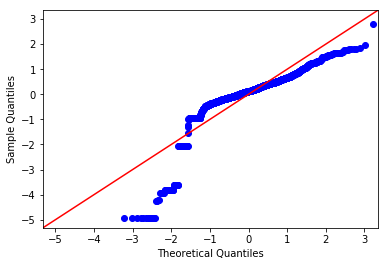

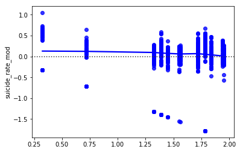

```python
res_N = results_N.resid
fig_N = sm.qqplot(res_N,fit=True, line='45')
plt.show()

sns.residplot(resultsCV.predict(X_train), y_train, lowess=True, color="b")
```

North Europe OLS analysis: By fitting a linear model for Northern Europe, we have seen that "generation", "HDI", "GDPC" and some "age" have p-values above 5% significant level. So we decide to remove these variables. After we have done such data modification base on the summary output form our model, cross validation is used to further aid our analysis. Applying cross validation at 70-30 split to compare the effect of our data modification and variable selection, we manage to bring the MSE down to 0.1123. That means only age and gender have effect on suicide rate. The QQplot and residual plot is not better.

```python
#northeurope GLM
glmmodel = smf.glm('suicide_rate_mod ~ sex + age', data = northeurope, family=sm.families.Gaussian())
glmresults = glmmodel.fit()
glmresults.summary()
```

Generalized Linear Model Regression Results

| Dep. Variable: | suicide_rate_mod | No. Observations: | 1532 |
| --- | --- | --- | --- |
| Model: | GLM | Df Residuals: | 1525 |
| Model Family: | Gaussian | Df Model: | 6 |
| Link Function: | identity | Scale: | 0.13445 |
| Method: | IRLS | Log-Likelihood: | -633.28 |
| Date: | Thu, 06 Jun 2019 | Deviance: | 205.04 |
| Time: | 11:06:08 | Pearson chi2: | 205. |
| No. Iterations: | 3 | Covariance Type: | nonrobust |

|  | coef | std err | z | P>\|z\| | [0.025 | 0.975] |
| --- | --- | --- | --- | --- | --- | --- |
| Intercept | 1.3192 | 0.025 | 53.284 | 0.000 | 1.271 | 1.368 |
| sex[T.male] | 0.4095 | 0.019 | 21.855 | 0.000 | 0.373 | 0.446 |
| age[T.25-34 years] | 0.1175 | 0.032 | 3.624 | 0.000 | 0.054 | 0.181 |
| age[T.35-54 years] | 0.2207 | 0.032 | 6.811 | 0.000 | 0.157 | 0.284 |
| age[T.5-14 years] | -0.9748 | 0.033 | -29.959 | 0.000 | -1.039 | -0.911 |
| age[T.55-74 years] | 0.2318 | 0.032 | 7.153 | 0.000 | 0.168 | 0.295 |
| age[T.75+ years] | 0.0756 | 0.032 | 2.332 | 0.020 | 0.012 | 0.139 |

```python
from sklearn.model_selection import train_test_split
X_northeurope = northeurope[['sex' ,  'age' , 'HDI' , 'generation', 'gdp' , 'gdpc']]
X_northeurope.dropna()
X_train, X_test, y_train, y_test = train_test_split(X_northeurope, northeurope.suicide_rate_mod, test_size=0.3, random_state=0)


X_train['suicide_rate'] = y_train
X_train.head()

cvmodel = smf.glm('suicide_rate ~ sex + age + generation + gdpc + HDI', data = X_train)
resultsCV = cvmodel.fit()
cvPredictionLM = resultsCV.predict(X_test)
#MSE
np.mean((cvPredictionLM - y_test)**2)
```

```
0.10845949037916978
```

North Europe GLM analysis: A similar approach is adopted by using generalized linear model. Using the same process as the linear model, we have seen similar effects from the predictors, indicating similar conclusions can be drawn.

# From here we remove rows where suicide rate is 0.

### Why there are many zeros:

We look up the country Bahrain, which has the highest number of 0. Research shows that available data of Bahrain is very limited, and Bahrain is a Islamic country. One of Islam religious faith is prohibit suicide. So we think this also helps decrease the suicide rates in Bahrain. In addition, more research is needed on the epidemiology of suicide risk factors in ethnic groups for further prevention and intervention. Thus, for countries have many zero suicide rates, we need to do more background research.

```python
model_i = smf.ols('suicide_rate_mod ~  sex + age + generation + HDI + gdpc', data = israel)
results_i = model_i.fit()
results_i.summary()
```

[output not shown]

```python
zero = both[both.suicide_rate == 0].groupby('country').count()
zero['country']=zero.index
zero1 = zero[['country','group']]
zero1['code']=['BHR','CYP','DNK','FIN','ISL','ISR','NOR','OMN','QAT','SWE']
zero1
```

| country | country | group | code |
| --- | --- | --- | --- |
| Bahrain | Bahrain | 146 | BHR |
| Cyprus | Cyprus | 80 | CYP |
| Denmark | Denmark | 20 | DNK |
| Finland | Finland | 15 | FIN |
| Iceland | Iceland | 118 | ISL |
| Israel | Israel | 20 | ISR |
| Norway | Norway | 14 | NOR |
| Oman | Oman | 25 | OMN |
| Qatar | Qatar | 96 | QAT |
| Sweden | Sweden | 7 | SWE |

```python
israelNOZERO = israel.loc[israel.suicide_rate != 0]
```

```python
modelNoZero_i = smf.ols('suicide_rate_mod ~  sex + age + generation + HDI + gdpc', data = israelNOZERO)
resultsNoZero_i = modelNoZero_i.fit()
resultsNoZero_i.summary()
```

OLS Regression Results

| Dep. Variable: | suicide_rate_mod | R-squared: | 0.930 |
| --- | --- | --- | --- |
| Model: | OLS | Adj. R-squared: | 0.927 |
| Method: | Least Squares | F-statistic: | 290.6 |
| Date: | Thu, 06 Jun 2019 | Prob (F-statistic): | 1.53e-155 |
| Time: | 12:15:05 | Log-Likelihood: | 294.38 |
| No. Observations: | 298 | AIC: | -560.8 |
| Df Residuals: | 284 | BIC: | -509.0 |
| Df Model: | 13 |  |  |
| Covariance Type: | nonrobust |  |  |

|  | coef | std err | t | P>\|t\| | [0.025 | 0.975] |
| --- | --- | --- | --- | --- | --- | --- |
| Intercept | 1.9089 | 0.298 | 6.415 | 0.000 | 1.323 | 2.495 |
| sex[T.male] | 0.3601 | 0.011 | 33.568 | 0.000 | 0.339 | 0.381 |
| age[T.25-34 years] | 0.0844 | 0.022 | 3.894 | 0.000 | 0.042 | 0.127 |
| age[T.35-54 years] | 0.1737 | 0.034 | 5.164 | 0.000 | 0.107 | 0.240 |
| age[T.5-14 years] | -0.6373 | 0.027 | -24.012 | 0.000 | -0.690 | -0.585 |
| age[T.55-74 years] | 0.2984 | 0.053 | 5.654 | 0.000 | 0.195 | 0.402 |
| age[T.75+ years] | 0.4566 | 0.062 | 7.325 | 0.000 | 0.334 | 0.579 |
| generation[T.G.I. Generation] | 0.0872 | 0.049 | 1.794 | 0.074 | -0.008 | 0.183 |
| generation[T.Generation X] | 0.0408 | 0.027 | 1.521 | 0.129 | -0.012 | 0.094 |
| generation[T.Generation Z] | 0.1830 | 0.062 | 2.959 | 0.003 | 0.061 | 0.305 |
| generation[T.Millenials] | 0.0951 | 0.041 | 2.329 | 0.021 | 0.015 | 0.176 |
| generation[T.Silent] | -0.0401 | 0.034 | -1.194 | 0.233 | -0.106 | 0.026 |
| HDI | -0.8131 | 0.388 | -2.094 | 0.037 | -1.577 | -0.049 |
| gdpc | -4.458e-06 | 1.53e-06 | -2.918 | 0.004 | -7.47e-06 | -1.45e-06 |

| Omnibus: | 1.258 | Durbin-Watson: | 2.075 |
| --- | --- | --- | --- |
| Prob(Omnibus): | 0.533 | Jarque-Bera (JB): | 1.007 |
| Skew: | -0.034 | Prob(JB): | 0.604 |
| Kurtosis: | 3.277 | Cond. No. | 2.46e+06 |

Warnings:  
[1] Standard Errors assume that the covariance matrix of the errors is correctly specified.  
[2] The condition number is large, 2.46e+06. This might indicate that there are  
strong multicollinearity or other numerical problems.

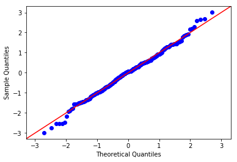

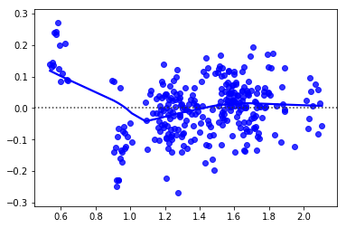

```python
res_N_o_i = resultsNoZero_i.resid
fig_N_o = sm.qqplot(res_N_o_i,fit=True, line='45')
plt.show()

sns.residplot(resultsNoZero_i.fittedvalues, res_N_o_i, lowess=True, color="b")
```

```python
northeuropeNOZERO = northeurope.loc[northeurope.suicide_rate != 0]
```

```python
#northeurope_no_zero OLS
modelNoZero = smf.ols('suicide_rate_mod ~ sex + age + generation + HDI', data = northeuropeNOZERO)
resultsNoZero = modelNoZero.fit()
resultsNoZero.summary()
```

OLS Regression Results

[output not shown]

[output not shown]

| Omnibus: | 17.900 | Durbin-Watson: | 1.708 |
| --- | --- | --- | --- |
| Prob(Omnibus): | 0.000 | Jarque-Bera (JB): | 23.954 |
| Skew: | -0.157 | Prob(JB): | 6.29e-06 |
| Kurtosis: | 3.564 | Cond. No. | 2.89e+06 |

Warnings:  
[1] Standard Errors assume that the covariance matrix of the errors is correctly specified.  
[2] The condition number is large, 2.89e+06. This might indicate that there are  
strong multicollinearity or other numerical problems.

```python
from sklearn.model_selection import train_test_split
X_northeurope = northeuropeNOZERO[[ 'sex' , 'generation' , 'age' , 'HDI' ,'gdpc']]
X_northeurope.dropna()
X_train, X_test, y_train, y_test = train_test_split(X_northeurope, northeuropeNOZERO.suicide_rate_mod, test_size=0.3, random_state=0)


X_train['suicide_rate'] = y_train
X_train.head()

cvmodel = smf.ols('suicide_rate ~ sex + age + generation + gdpc + HDI', data = X_train)
resultsCV = cvmodel.fit()
cvPredictionLM = resultsCV.predict(X_test)
#MSE
np.mean((cvPredictionLM - y_test)**2)
```

```
0.020602812186752056
```

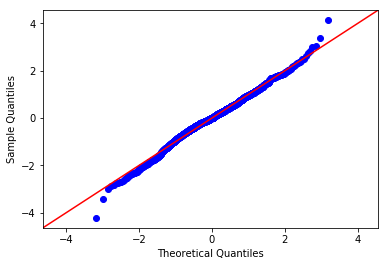

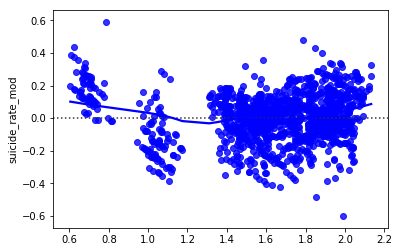

```python
res_N_o = resultsNoZero.resid
fig_N_o = sm.qqplot(res_N_o,fit=True, line='45')
plt.show()

sns.residplot(resultsNoZero.fittedvalues, northeuropeNOZERO.suicide_rate_mod, lowess=True, color="b")
```

```python
#northeurope_no_zero GLM
glmmodel = smf.glm('suicide_rate_mod ~ sex + age + generation +  HDI', data = northeuropeNOZERO, family=sm.families.Gaussian())
glmresults = glmmodel.fit()
glmresults.summary()
```

Generalized Linear Model Regression Results

| Dep. Variable: | suicide_rate_mod | No. Observations: | 1381 |
| --- | --- | --- | --- |
| Model: | GLM | Df Residuals: | 1368 |
| Model Family: | Gaussian | Df Model: | 12 |
| Link Function: | identity | Scale: | 0.020406 |
| Method: | IRLS | Log-Likelihood: | 734.35 |
| Date: | Wed, 05 Jun 2019 | Deviance: | 27.915 |
| Time: | 23:52:14 | Pearson chi2: | 27.9 |
| No. Iterations: | 3 | Covariance Type: | nonrobust |

|  | coef | std err | z | P>\|z\| | [0.025 | 0.975] |
| --- | --- | --- | --- | --- | --- | --- |
| Intercept | 2.7438 | 0.107 | 25.636 | 0.000 | 2.534 | 2.954 |
| sex[T.male] | 0.3506 | 0.008 | 45.508 | 0.000 | 0.336 | 0.366 |
| age[T.25-34 years] | 0.0997 | 0.015 | 6.861 | 0.000 | 0.071 | 0.128 |
| age[T.35-54 years] | 0.1878 | 0.021 | 8.904 | 0.000 | 0.146 | 0.229 |
| age[T.5-14 years] | -0.7430 | 0.018 | -40.328 | 0.000 | -0.779 | -0.707 |
| age[T.55-74 years] | 0.2064 | 0.031 | 6.664 | 0.000 | 0.146 | 0.267 |
| age[T.75+ years] | 0.2468 | 0.037 | 6.758 | 0.000 | 0.175 | 0.318 |
| generation[T.G.I. Generation] | 0.0013 | 0.031 | 0.041 | 0.967 | -0.059 | 0.061 |
| generation[T.Generation X] | 0.0025 | 0.017 | 0.146 | 0.884 | -0.031 | 0.036 |
| generation[T.Generation Z] | 0.0831 | 0.037 | 2.244 | 0.025 | 0.011 | 0.156 |
| generation[T.Millenials] | 0.0348 | 0.024 | 1.428 | 0.153 | -0.013 | 0.083 |
| generation[T.Silent] | -0.0085 | 0.021 | -0.403 | 0.687 | -0.050 | 0.033 |
| HDI | -1.5270 | 0.131 | -11.655 | 0.000 | -1.784 | -1.270 |

```python
from sklearn.model_selection import train_test_split
X_northeurope = northeuropeNOZERO[[ 'sex' , 'age' , 'generation' , 'HDI']]
X_northeurope.dropna()
X_train, X_test, y_train, y_test = train_test_split(X_northeurope, northeuropeNOZERO.suicide_rate_mod, test_size=0.2, random_state=0)


X_train['suicide_rate'] = y_train
X_train.head()

cvmodel = smf.glm('suicide_rate ~ sex + age + generation + HDI', data = X_train)
resultsCV = cvmodel.fit()
cvPredictionLM = resultsCV.predict(X_test)
#MSE
np.mean((cvPredictionLM - y_test)**2)
```

```
0.019448693180894698
```

# Conclusion & Reflection

Generally, age, gender, generation, GDP per capita as well as HDI are all significant predictors of suicide rate. But in different areas, they may have different effect.

Since gender, age, HDI and GDPC are all significant factors in our analysis. In order to decrease suicide rates, there are many things we could do. We should promote gender equality to avoid stereotypes such as men should suppress emotions. We should also advocate care for mental health and improve accessibility of therapies. Since the elders have high suicide rates, the society should care more about retired people and make sure they are economically grounded. Countries can also develop social standard to achieve higher HDI and GDPC.

Reflections:

- We only analyzed five countries from each region, and these countries are pretty small. We could increase our data to more countries to get more detailed analysis.
- There are many factors such as religion, belief, social changes, and social opinions about suicides and access to mental health assistance are now included in this dataset. In order to get a holistic view about that's truly behind suicides, much more research need to be done.
- When we remove 0s for modeling, the r-square may increase, but the completeness of the data is sacrificed.

## References

- https://econtent.hogrefe.com/doi/abs/10.1027/0227-5910.28.1.11?rfr_dat=cr_pub%3Dpubmed&url_ver=Z39.88-2003&rfr_id=ori%3Arid%3Acrossref.org&journalCode=cri
- https://genhq.com/faq-info-about-generations/
- http://hdr.undp.org/en/data
- https://www.theguardian.com/science/2015/jan/21/suicide-gender-men-women-mental-health-nick-clegg